# The Brief:

> **Client:** Rolling Beats Magazine (music publication)

> **Your role:** Data Journalist

> **Context:** Rolling Beats is preparing their "25 Years of Pop" retrospective issue. The editorial team wants data-driven stories that reveal how popular music has evolved since 2000. They're looking for surprising trends, cultural shifts, and compelling visualizations that tell the story of modern pop.

> You have access to 25 years of Billboard Hot 100 chart data (2000-2024), combined with Spotify's audio analysis of each track.

> **Your task:** Explore 25 years of chart data and uncover the stories hidden within. What trends emerge? What has changed, and what has stayed the same? Find insights that would make readers say "I never knew that."

Creative Idea: Felix Weiland

Execution: Melina Torstensson

# The Editorial:

# **ROLLING BEATS MAGAZINE**

#### The Greatest Song in the World

##### (A Tenasiuos D Tribute)

*Story by Melina Torstensson*

## The greatest song in the world.

The year is 2002. Life is good, the music produced is excellent, long before the era of algorithmic playlists and AI tunes. The world is a beautiful place.

Two hitchhikers named Jack and Kyle are walking down a long and lonesome road, when they all of a sudden are stoped by a shine before them. At first glance, it appears to be a deamon, but the swamp tail alludes to him being the Devil himself. He calls upon the two hikers to play the best song in the world, else, he will eat their soul.

The men had no choice, they played the first thing that came to thier heads, and it just so happened to be the best song in the world. The Devil stared, a whip crach went through his tail, the beast was stunned. The men were saved! But what song was it you may ask? Unfortunately, they dont remember. To quote them directly:

"Couldn't remember the greatest song in the world [...] It was

the greatest song in the world alright."

But could we potentially find out?

Jack and Kyle sing of the greatest song in the world, to our help we have the Billboard Hot 100.

but they are also americans, a people with little knowledge about the outside world. It is possible, that to them, the whole world actually is the USA, meaning, we have to look no further than to the Billboard Hot 100. We also know that the event took place somewhere before June of 2002, so the song cannot have appeard after.

Next, we need to discuss what exactly makes 'the best song in the world'. Is it the longest rule at #1?, or the longest time in top 10? Longest consicutive rule at #1?

## Top Songs

Depending on which metric we use we see different songs in the top.

Ps, the scoring is made using a normalisation number (see below), however for reader interest the songs total number of weeks is plotted on the Y-axis.

[figure not shown]

```python
fig_2002
```

### The Soul Saving Index. (SSI)

The greatest song in the world is the song of songs. It doesnt just make number 1 once, it stays in peoples hearts. It holds it place and it lingers. We never stop singing it.

The song that saved Kyle and Jack was a combination of all, following a simple mathematical equation - a pythonic function - of the Soul Saving Index (SSI):

(Longest time at #1 * 0.35) + (Longest concecutive time at #1 * 0.45) + (Longest time in top10 * 0.20)

### Solving the streaming mess

Due to the rise of streaming, it has become easier for tracks to hold the #1 spot for much longer periods.

**To make the calculations as precise as possible each year has a "normalisation number"**:

It referes to the maximum times a track held the #1 spot that year. Or the maximal number of weeks spent in top10 that year. Every equation is then normalised using those numbers.

Maria Maria's normalisation score is 12/12 = 1.0

Say My Name's normalisation score is 10/12 = 0.8

Each calculation - total time at #1 / concecutive weeks at #1 / time in top10 has a separate normalisation score.

**Each SSI-calculation has a "local" normalisation number**

Since every year has a normalisation number, a track topping the list over more than one year would appear once per year. Instead a "local" normalisation number for the date range is calculated using a track specific mean:

example: How You Remind Me (Nickelback) had a normalisation number of 7 in 2001 / 17 in 2002. Nickelbacks local normalisation number is (7+17)/2= 12.

### Which song saved Jack and Kyle back in 2002? And which song would have saved them today?

Turns out, maybe against popular believes, the song that save Jack and Kyle was not a rock song. It turns out, the devil at the time was a Destinys Child fan. Who knew right?

If we look to some later dates. We see something very interesting. The Devil seems to have a very special place in his heart for Beyoncé. The queen herself. And not only that! His top song has not changed since 2010. Beyoncés 'Irreplaceable' has a strong hold on the top position. As they say - oncec a banger, always a banger.

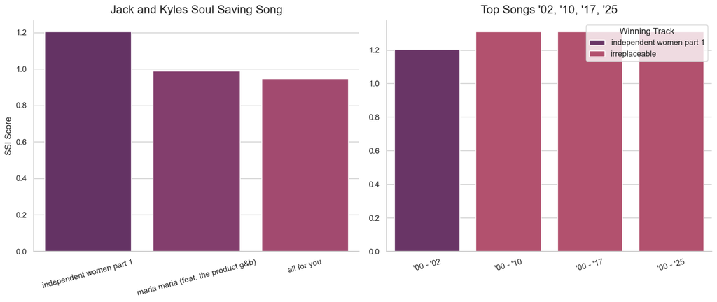

```python
fig_ssi
```

### What defines a soul saving song?

The Devil has a sad heart rather than happy. Originally he was into more of a walking pace of song. It may seem as he later picked up the pace, but deep diving (and actually listening to the song) shows that he might have slowed down both tempo and sass to a melancolic 88 bpm.

```python
info_box_winners
```

|  | date_range_short | name_track | name_artists | key | mode | tempo |
| --- | --- | --- | --- | --- | --- | --- |
| 0 | '00 - '02 | Independent Women Part 1 | Destiny'S Child | F# | Minor | 98.0 |
| 1 | '00 - '10 | Irreplaceable | Beyoncé | G | Minor | 176.0 |
| 2 | '00 - '17 | Irreplaceable | Beyoncé | G | Minor | 176.0 |
| 3 | '00 - '25 | Irreplaceable | Beyoncé | G | Minor | 176.0 |

Althou the '02 song being in minor it gives a laid back feeling of being on top of the world. Tempo is moderate, suitable for a playfull dance around in your high heels snaping your fingers. Energy or loudness aren't to high, but does it really need to be when you're just so sure of yourself?

We wont ever know what really happend inbetween '02 and 10', all we know is someting changed. Valence dropped, danceability dropped and loudness rose. Instead of a laid back, careless slide and step down the street, we now walk head down, headphones on. We seem to have froze here. What magical hold does Beyoncés 'Irreplaceable' has on the Devil, making it the greatest song in the world for 15 years?

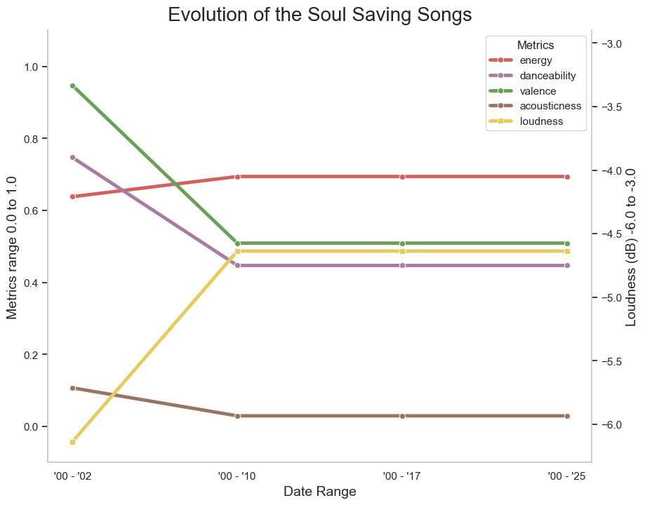

```python
fig_line
```

### Does the Devil love Beyoncé?

Looks like it. These finding might not be the most groudbreaking posing alot of analysis in how his taste has changed over time, but they also should calm us rather than alarm us. If you ever walk down a long and lonesome road, if ever there shines a shiny light ahead. Beyoncé might well save your life. That lady is truly irreplaceable.